# Economía de La Rioja

Informe económico y de Economía del Conocimiento

Autor/a

Elaboración propia

Fecha de publicación

septiembre 2026

# 1 Resumen ejecutivo

La economía de La Rioja atraviesa una fase de retracción estructural que se manifiesta en tres planos simultáneos: caída del producto provincial, pérdida de empleo registrado y deterioro del salario real frente a la Nación. A esto se suma, en 2026, un cuadro fiscal crítico: la provincia registra **la peor performance recaudatoria del país** (−13,2% real acumulado a agosto, contra −3,0% del consolidado nacional).

El diagnóstico resultante es el de una economía provincial en divergencia: el sector primario y los servicios tradicionales sostienen el nivel de actividad, mientras los segmentos de mayor productividad —industria, servicios técnicos, EC— pierden peso relativo.

# 2 Contexto macroeconómico

## 2.1 Producto provincial (OPEX)

La serie del Producto Bruto Geográfico del Instituto Nacional de Estadística y Censos (base OPEX, metodología homogénea 1993–2025) permite seguir la evolución del valor agregado provincial en términos reales.

**Nota**

**Definición.** El VAB (Valor Agregado Bruto) provincial que publica OPEX es un agregado macro sin apertura sectorial. No permite descomponer la contribución de la Economía del Conocimiento ni de otros sectores específicos. Para el análisis sectorial se usa el Registro de Empresas y el SIPA–OEDE.

En 2025, La Rioja aportó USD 163,4 millones al VAB nacional. Se trata de la participación más baja desde el inicio de la serie comparable: en 1993 representaba 0,36% del total país; en 2025, 0,19%. La trayectoria no es un artefacto del año: la caída es sostenida desde 2011.

| Indicador | 1993 | 2011 | 2024 | 2025 |
| --- | --- | --- | --- | --- |
| VAB La Rioja (USD M) | — | — | — | 163,4 |
| Participación nacional | 0,36% | 0,28% | 0,21% | 0,19% |
| Var. interanual | — | — | — | −25,7% |
| Var. nacional | — | — | — | +9,3% |

## 2.2 Situación fiscal 2026: la peor del país

Según datos de la DNAP/CEPA (*Series de Recaudación Provincial*, actualizado al 11/09/2026), La Rioja es la jurisdicción con peor desempeño fiscal del país en 2026:

| Indicador | La Rioja | Consolidado nacional |
| --- | --- | --- |
| Variación real acumulada 2026 (total recaudación) | **−13,2%** | −3,0% |
| Variación real acumulada 2026 (Ingresos Brutos) | **−14,1%** | — |
| Peor mes (agosto 2026) | **−22,5%** | −11,2% |

**Meses críticos 2026:**

| Mes | Total recaudación (var. real i.a.) | II.BB (var. real i.a.) |
| --- | --- | --- |
| Enero | −20,0% | −20,5% |
| Febrero | −10,8% | −8,8% |
| Marzo | −14,2% | −16,1% |
| Abril | −6,5% | −5,9% |
| Mayo | −8,7% | −9,5% |
| Junio | −7,9% | −11,3% |
| Julio | −12,9% | −13,3% |
| Agosto | **−22,5%** | **−24,7%** |
| **Acumulado** | **−13,2%** | **−14,1%** |

# 3 Empleo registrado

## 3.1 Fuente y método

El análisis de empleo usa la serie SIPA–OEDE (Sistema Integrado Previsional Argentino – Observatorio de Empleo y Dinámica Empresarial, dependiente de la Secretaría de Trabajo, Empleo y Seguridad Social). Los datos están desestacionalizados y expresados como índice base enero 2019 = 100.

## 3.2 Trayectoria 2019–2026

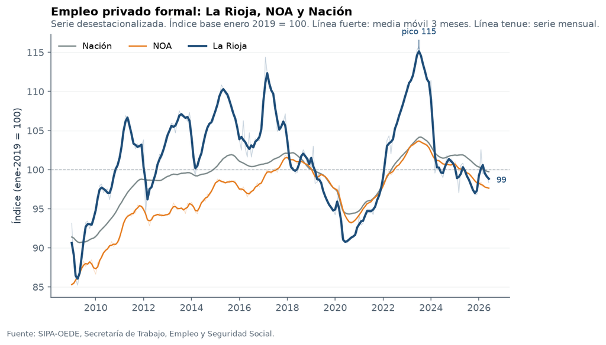

Figura 1: Empleo registrado privado formal: La Rioja, NOA y Nación. Índice base enero 2019 = 100, serie desestacionalizada. Fuente: SIPA–OEDE.

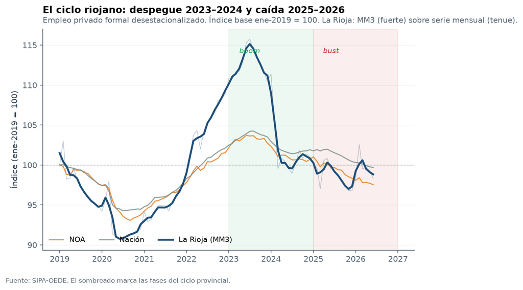

Figura 2: Zoom sobre la reversión 2024–2026: La Rioja pierde el diferencial positivo construido entre 2021 y 2024.

En el cuarto trimestre de 2025 la provincia registró 28.442 puestos de trabajo registrados en el sector privado.

## 3.3 Comparación regional

[output not shown]

# 4 Salarios

## 4.1 Salario nominal

En marzo de 2026 el salario promedio del trabajador registrado en La Rioja fue de $1.310.000, contra $2.210.000 en la Nación y $1.570.000 en el NOA.

| Jurisdicción | Marzo 2026 | Ratio vs Nación |
| --- | --- | --- |
| Nación | $2,21 M | 1,00 |
| NOA | $1,57 M | 0,71 |
| La Rioja | $1,31 M | 0,59 |

## 4.2 Salario real

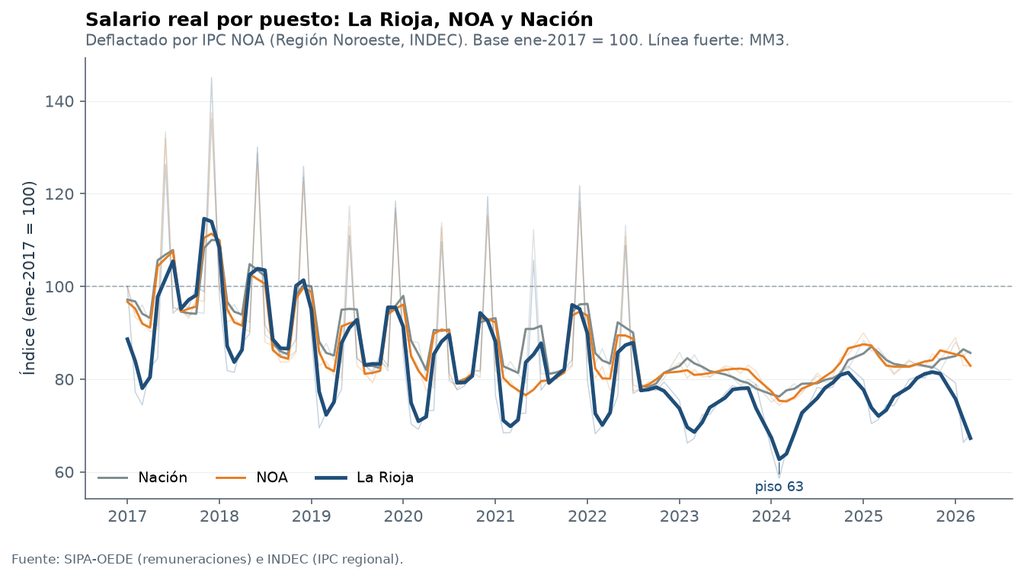

[output not shown]

La caída total 2017–2024 fue del −35,3%; la recuperación 2024–2025 recuperó 15,1 puntos, aunque el nivel sigue 20 puntos por debajo del punto de partida.

## 4.3 Ratio salarial provincial / nacional

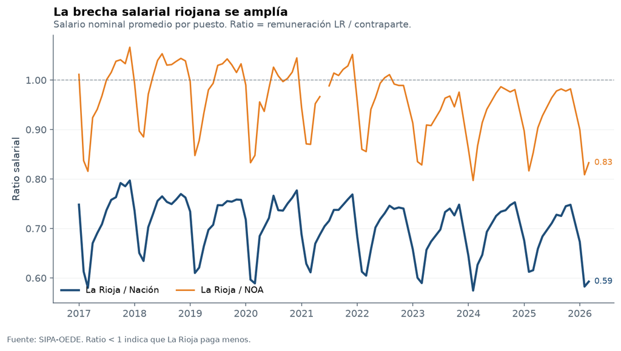

Figura 4: Ratio entre el salario promedio de La Rioja y el de la Nación. Un valor de 0,59 indica que un trabajador riojano gana 59 centavos por cada peso del promedio nacional.

El ratio pasó de 0,72 en 2019 a 0,59 en 2026: 13 puntos de deterioro relativo en siete años.

# 5 Recaudación EC

## 5.1 Definición y método

La **Recaudación EC** es la porción de **Ingresos Brutos (II.BB)** provincial correspondiente a las actividades de Economía del Conocimiento definidas en el apartado Actividades de Economía del Conocimiento. **No es un impuesto separado**: se recauda a través del régimen general de II.BB, con tratamiento específico bajo el régimen de Economía del Conocimiento.

**Nota**

**Fuentes.** - Serie de II.BB provincial: DNAP/CEPA, *Series de Recaudación Provincial* (actualizado 11/09/2026). - Serie de Recaudación EC: DGIP La Rioja, padrón de contribuyentes por régimen (2022-2025). - Análisis consolidado: `src/recaudacion_ec.py`.

## 5.2 Serie 2022-2025

| Año | Contrib. Multilateral | Contrib. Locales | Recaudación EC | II.BB total | Share EC |
| --- | --- | --- | --- | --- | --- |
| 2022 | 1.752 | 1.138 | $58,99 M | $11.588,96 M | **0,51%** |
| 2023 | 1.911 | 1.060 | $243,01 M | $26.779,40 M | **0,91%** |
| 2024 | 1.947 | 844 | $846,13 M | $83.422,68 M | **1,01%** |
| 2025 | 2.075 | 840 | **$1.940,91 M** | **$125.549,36 M** | **1,55%** |

**Fuente:** DGIP La Rioja + DNAP/CEPA. II.BB en millones de pesos corrientes.

## 5.3 Dinámica comparada: EC vs. II.BB total

Entre 2022 y 2025, ambos agregados crecieron en términos nominales, pero a ritmos muy distintos:

- **Recaudación EC:** ×32,9 ($58,99 M → $1.940,91 M)
- **II.BB total:** ×10,8 ($11.588,96 M → $125.549,36 M)
- **Ratio de crecimiento:** el EC crece **3,0 veces más rápido** que la base total

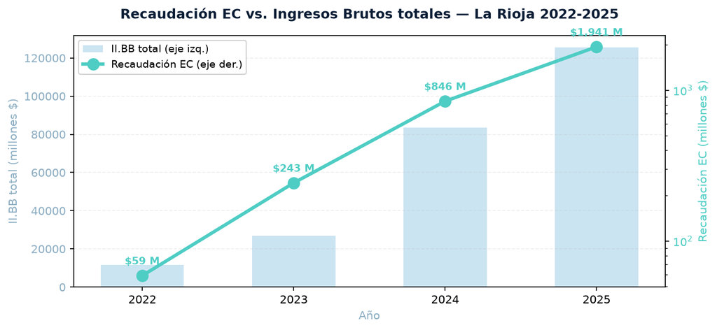

Figura 5: Recaudación EC vs. Ingresos Brutos totales — La Rioja 2022-2025. Barras: II.BB en eje izquierdo. Línea: Recaudación EC en eje derecho (escala logarítmica). Fuente: DGIP La Rioja + DNAP/CEPA.

## 5.4 Peso del EC sobre II.BB

El share del EC sobre la base imponible provincial pasó de **0,51% (2022)** a **1,55% (2025)**, un crecimiento de **×3,0 en cuatro años**.

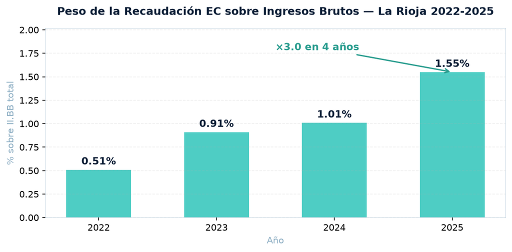

Figura 6: Peso de la Recaudación EC sobre Ingresos Brutos — La Rioja 2022-2025. La participación se triplicó en cuatro años, aunque aún representa una porción minoritaria de la base imponible. Fuente: DGIP La Rioja + DNAP/CEPA.

**Importante**

**Hallazgo principal.** La Recaudación EC crece a un ritmo **3 veces superior** al del II.BB total. Sin embargo, su peso sobre la base imponible todavía es bajo (1,55%). Duplicarlo requeriría sostener el ritmo de crecimiento por varios años más.

## 5.5 Crecimiento comparado (índice 2022 = 100)

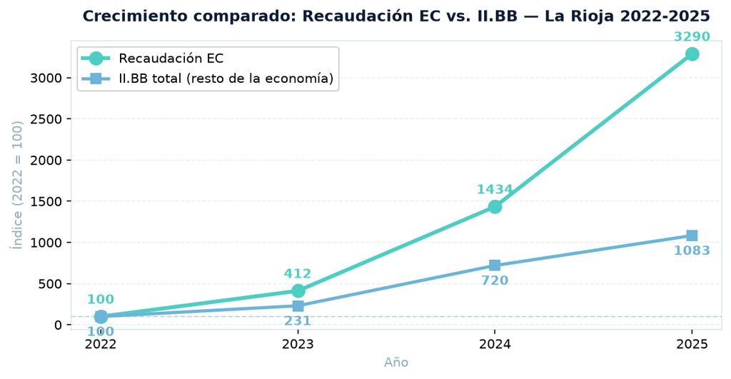

Figura 7: Crecimiento comparado: Recaudación EC vs. II.BB total — La Rioja 2022-2025 (índice 2022=100). La Recaudación EC multiplicó su valor por 32,9, mientras el II.BB total lo hizo por 10,8. Fuente: DGIP La Rioja + DNAP/CEPA.

| Año | Recaudación EC (índice) | II.BB total (índice) | Brecha (pp) |
| --- | --- | --- | --- |
| 2022 | 100,0 | 100,0 | 0 |
| 2023 | 412,0 | 231,1 | +181 |
| 2024 | 1.434,4 | 719,8 | +715 |
| 2025 | **3.290,2** | **1.083,4** | **+2.207** |

La brecha acumulada entre ambos agregados es de **+2.207 pp** al cierre de 2025.

## 5.6 Contribuyentes: migración Locales → Convenio Multilateral

El padrón EC muestra una recomposición estructural: los contribuyentes **Locales** caen (−26,2%), mientras los de **Convenio Multilateral** crecen (+18,4%). El share de Multilateral pasó de **60,6% (2022)** a **71,2% (2025)**.

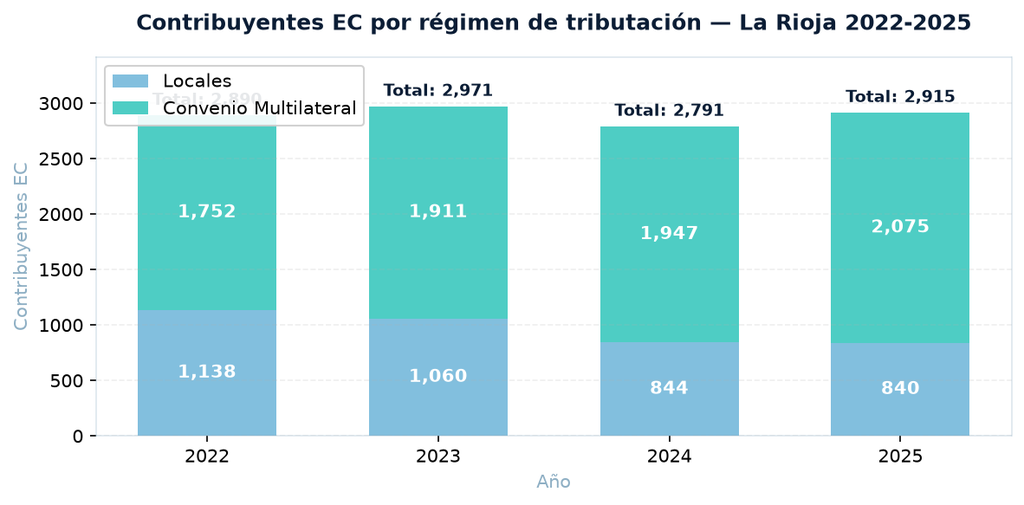

Figura 8: Contribuyentes EC por régimen de tributación — La Rioja 2022-2025. La migración de Locales a Convenio Multilateral sugiere profesionalización del padrón: firmas que crecen y pasan de tributar localmente a hacerlo bajo Convenio. Fuente: DGIP La Rioja.

| Año | Locales | Multilateral | Total | Share Multilateral |
| --- | --- | --- | --- | --- |
| 2022 | 1.138 | 1.752 | 2.890 | 60,6% |
| 2023 | 1.060 | 1.911 | 2.971 | 64,3% |
| 2024 | 844 | 1.947 | 2.791 | 69,8% |
| 2025 | 840 | 2.075 | 2.915 | **71,2%** |

**Interpretación:** la caída de contribuyentes Locales no implica desaparición de firmas, sino **traspaso al régimen de Convenio Multilateral**. Es un patrón esperable cuando las empresas del sector crecen y comienzan a operar en más de una jurisdicción.

## 5.7 Contexto fiscal 2026

Según la DNAP/CEPA (actualizado 11/09/2026), La Rioja acumula una caída real de **−13,2%** en recaudación total durante 2026, y de **−14,1%** en Ingresos Brutos. Es la peor performance fiscal del país: el consolidado nacional cae −3,0% en el mismo período.

| Indicador | La Rioja | Consolidado nacional |
| --- | --- | --- |
| Var. real acum. 2026 (total) | **−13,2%** | −3,0% |
| Var. real acum. 2026 (II.BB) | **−14,1%** | — |
| Peor mes (agosto 2026) | **−22,5%** | −11,2% |

**Advertencia**

**Dato pendiente.** El dato oficial de Recaudación EC para 2026 **aún no está publicado**. La serie 2026 se cierra cuando la DGIP publique el padrón actualizado. Debe solicitarse formalmente.

## 5.8 Síntesis de la sección

| Indicador | Valor | Cambio 2022 → 2025 |
| --- | --- | --- |
| Recaudación EC | $1.940,91 M (2025) | ×32,9 |
| II.BB total | $125.549,36 M (2025) | ×10,8 |
| Share EC / II.BB | 1,55% (2025) | +1,04 pp |
| Contribuyentes Locales | 840 (2025) | −26,2% |
| Contribuyentes Multilateral | 2.075 (2025) | +18,4% |
| Recaudación total prov. (2026) | — | −13,2% real |
| II.BB prov. (2026) | — | −14,1% real |

**Conclusión de la sección:** La Recaudación EC es el agregado de II.BB que más rápido crece en La Rioja, multiplicando su participación por 3 en cuatro años. No obstante, su peso sobre la base imponible provincial (1,55%) todavía es modesto. En un contexto de caída real generalizada de la recaudación provincial (−13,2% en 2026), el sector EC funciona como vector positivo, pero su escala actual es insuficiente para revertir la tendencia agregada.

# 6 Actividades de Economía del Conocimiento

## 6.1 Definición y fuente

El análisis de empresas y empleo del sector EC usa el registro SIPA – Observatorio de Empleo y Dinámica Empresarial (STEySS), serie provincial con apertura CIIU rev. 3 a 4 dígitos. La definición adoptada es la de **Actividades EC (AFIP/ARCA)**, que identifica las actividades de Economía del Conocimiento a partir de los códigos CIIU equivalentes a las actividades promovidas por la Ley 27.506 y su modificatoria 27.570.

**Nota**

**Códigos CIIU EC (Actividades de Economía del Conocimiento)**

| CIIU | Actividad |
| --- | --- |
| 7210 | Consultores en equipo y programas informáticos |
| 7220 | Consultores y suministros de programas informáticos |
| 7250 | Reparación de maquinaria de oficina, contabilidad e informática |
| 7290 | Actividades de informática n.c.p. |
| 7300 | Investigación y desarrollo experimental |
| 7421 | Servicios de arquitectura e ingeniería y geología |
| 7430 | Investigación y desarrollo de ciencias sociales y humanidades |
| 7499 | Otras actividades empresariales n.c.p. |

**Núcleo informático** = 7210 + 7220 + 7290 (definición canónica del proyecto). **Núcleo amplio** = núcleo informático + 7300 + 7430.

**Advertencia**

**Advertencia metodológica.** Los códigos **7421** (geología/arquitectura/ingeniería) y **7499** (diseño/traducción/cobranzas) son **proxies**: el SIPA no permite aislar la actividad EC específica dentro de ellos. Bajo esta definición, el **67,7% del conteo EC depende de estos dos proxies**. El conteo es un **techo superior**, no exacto. Excluye 9220 (agencias de noticias).

## 6.2 Evolución 2019–2025

[output not shown]

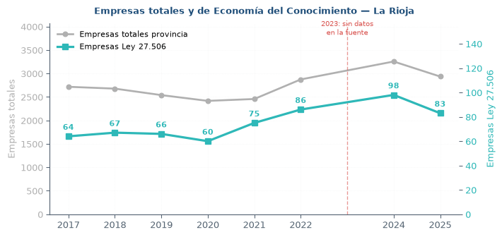

[output not shown]

## 6.3 Composición por bloque

| Bloque | 2019 | 2020 | 2021 | 2022 | 2024 | 2025 |
| --- | --- | --- | --- | --- | --- | --- |
| Software y SI | 6 | 11 | 17 | 25 | 28 | 25 |
| Ingeniería y geología (proxy) | 29 | 22 | 25 | 26 | 31 | 28 |
| Servicios profesionales (proxy) | 29 | 32 | 28 | 40 | 38 | 31 |
| Publicidad | 6 | 0 | 4 | 4 | 5 | 0 |

**Hallazgos:**

- El **software** se estancó entre 2022 y 2025 (25 → 28 → 25).
- **Publicidad colapsó a 0** en 2025.
- Los **proxies** (7421 + 7499) concentran el 67,7% del conteo EC.

# 7 Empleo EC

## 7.1 Definición y método

El empleo EC se calcula con la **definición de núcleo informático** (CIIU 7210, 7220, 7290), consistente con el resto del análisis (prima salarial, recaudación y empresas EC). La serie se construye como **stock promedio anual de puestos de trabajo**, calculado como el promedio de los cuatro trimestres de cada año.

**Nota**

**Por qué núcleo.** El CIIU 7210 (consultores en equipo) **no tiene dato de empleo ni de salario** en el archivo SIPA-OEDE 4 dígitos. En la práctica, el núcleo se calcula como suma de 7220 + 7290. Se mantiene 7210 en la definición porque integra el conjunto canónico EC del proyecto.

## 7.2 Serie 2019-2025

| Año | Empleo EC (núcleo) | Empleo total provincial | Participación |
| --- | --- | --- | --- |
| 2019 | 11,5 | 26.894 | **0,043%** |
| 2020 | 23,75 | 25.399 | **0,094%** |
| 2021 | 29,0 | 26.245 | **0,110%** |
| 2022 | 65,5 | 30.125 | **0,217%** |
| 2023 | 78,0 | 32.701 | **0,239%** |
| 2024 | 61,25 | 28.008 | **0,219%** |
| 2025 | 59,5 | 27.047 | **0,220%** |

**Fuente:** SIPA-OEDE (STEySS), CIIU 7220 + 7290. Empleo total: SIPA-OEDE, serie provincial desestacionalizada. Valores expresados como stock promedio anual de los 4 trimestres.

**Hallazgos:**

- El empleo EC del núcleo pasó de **11,5** (2019) a **59,5** puestos (2025): **+417%**.
- El pico fue **2023** con 78 puestos (0,239% del empleo provincial).
- Entre 2023 y 2025 el empleo EC cayó **−23,7%** (−21,5% si se compara 2024 vs. 2023).
- La participación en el empleo formal provincial pasó de **0,04%** a **0,22%**: se multiplicó por 5,5.

## 7.3 Salario por CIIU EC (dic-2025)

| CIIU | Rama | Salario | Prima vs. provincial |
| --- | --- | --- | --- |
| 7290 | Informática n.c.p. | $4.220.278 | **+100,5%** |
| 7220 | Consultores informáticos | $2.786.240 | +32,4% |
| 7421 | Arquitectura/ingeniería (proxy) | $1.566.575 | −25,6% |
| 7499 | Servicios empresariales (proxy) | $1.534.016 | −27,1% |
| 7210, 7250, 7300, 7430 | — | sin datos | — |

**Fuente:** SIPA-OEDE, remuneraciones mensuales por CIIU 4 dígitos, dic-2025. Salario provincial de referencia: $2.104.500 (con SAC).

**Hallazgos:**

- **Informática n.c.p. paga +100%** sobre el promedio provincial.
- Las ramas **proxy** (7421, 7499) pagan **25-27% por debajo** del promedio provincial.
- La definición completa de Actividades EC **diluye la prima** por el peso de las ramas proxy.
- En dic-2025, el CIIU 7250 (reparación de equipos) no tiene dato publicado (en dic-2024 sí tenía: $1.233.257, prima −24,4%).

## 7.4 Elasticidad empresas-empleo

La relación entre empresas EC y empleo del núcleo informático **se invirtió** entre 2022 y 2025:

[output not shown]

**Advertencia**

**Nota.** 2023 no tiene dato de empresas en SIPA-OEDE. 2025 es preliminar. Empleo EC: núcleo informático {7220, 7290}; CIIU 7210 sin dato en el archivo 4-dig.

## 7.5 Prima salarial EC

### 7.5.1 Tres definiciones

| Año | Núcleo informático | Núcleo amplio | Actividades EC completo |
| --- | --- | --- | --- |
| 2019 | −0,16% | −31,47% | −16,72% |
| 2020 | +46,16% | +46,16% | +18,90% |
| 2021 | +6,16% | −18,35% | −28,51% |
| 2022 | **+27,15%** | −4,62% | −15,39% |
| 2023 | **+62,03%** | +19,78% | −15,09% |
| 2024 | **+63,13%** | +63,13% | +10,22% |
| 2025 | **+66,46%** | +66,46% | **+20,06%** |

**Fuente:** SIPA-OEDE, serie de remuneraciones mensuales por CIIU 4 dígitos.

**Denominador:** salario provincial oficial ponderado por empleo, del mismo mes/año que el salario por CIIU (incluye SAC).

**Hallazgos:**

- La prima del **núcleo informático** se duplicó entre 2022 (+27,2%) y 2025 (+66,5%).
- La prima del **EC completo** es sensiblemente menor porque incluye las ramas proxy (7250, 7421, 7499) que pagan por debajo del promedio.
- La brecha núcleo vs. completo **se amplió** de 42,5 pp (2022) a 46,4 pp (2025).

# 8 Intensidad empresarial EC

| Provincia | 2022 | 2024 | 2025 | Δ pp (22→25) |
| --- | --- | --- | --- | --- |
| CABA | 67,30 | 67,95 | 68,64 | +1,34 |
| Catamarca | 39,18 | 43,18 | 44,69 | **+5,51** |
| Salta | 37,46 | 38,99 | 42,11 | +4,65 |
| Tucumán | 34,93 | 35,74 | 34,88 | −0,05 |
| Córdoba | 32,81 | 34,55 | 33,90 | +1,09 |
| Jujuy | 31,32 | 33,12 | 32,22 | +0,90 |
| **La Rioja** | **33,07** | **31,34** | **28,62** | **−4,45** 🔴 |
| Santa Fé | 27,06 | 27,29 | 27,18 | +0,12 |
| Santiago del Estero | 24,31 | 25,63 | 22,24 | −2,07 |

**Fuente:** SIPA-OEDE. Intensidad = (empresas EC / empresas totales) × 1.000.

# 9 Benchmark regional

[output not shown]

**Evolución de empresas EC en el NOA:**

[output not shown]

# 10 Conclusiones

# 11 Metodología

## 11.1 Fuentes

| Fuente | Serie | Cobertura temporal | Frecuencia |
| --- | --- | --- | --- |
| SIPA–OEDE (STEySS) | Empleo registrado privado formal | 1996–2026 | Mensual / trimestral |
| SIPA–OEDE (STEySS) | Empresas privadas por rama | 1996–2025 | Anual |
| SIPA–OEDE (STEySS) | Empleo por rama a 4 dígitos CIIU | 1996–2025 | Trimestral |
| SIPA–OEDE | Salario por rama a 4 dígitos CIIU | 1995–2025 | Mensual |
| SIPA–OEDE | Salario promedio registrado | 2010–2026 | Mensual |
| INDEC | IPC NOA | 2017–2026 | Mensual |
| INDEC (OPEX) | VAB provincial | 1993–2025 | Anual |
| INDEC | Exportaciones por complejidad | 2019–2024 | Anual |
| MINCyT | I+D, investigadores | 2013–2024 | Anual |
| ENACOM | Conectividad (accesos, fibra) | 2022–2026 | Trimestral |
| DGIP La Rioja | Ingresos brutos por actividad | 2018–2025 | Mensual |
| DGIP La Rioja | Contribuyentes por régimen | 2022–2025 | Anual |
| DNAP/CEPA | Recaudación provincial total y por tributo | 2019–2026 | Mensual |

## 11.2 Definiciones

**Empleo registrado (SIPA).** Asalariados registrados en el sector privado, según declaración al Sistema Integrado Previsional Argentino. Índice desestacionalizado base enero 2019 = 100.

**Empresas (SIPA–OEDE).** Empresas privadas activas por año, según apertura CIIU rev. 3 a 4 dígitos. Una empresa se cuenta una vez por año si registró al menos un asalariado en ese período.

**Actividades EC (AFIP/ARCA).** Conjunto de actividades de Economía del Conocimiento identificadas a partir de los códigos CIIU rev. 3 a 4 dígitos equivalentes a las actividades promovidas por la Ley 27.506 y su modificatoria 27.570. Incluye los códigos 7210, 7220, 7250, 7290, 7300, 7421, 7430, 7499. Excluye 9220 (agencias de noticias).

**Núcleo informático.** Subconjunto canónico de Actividades EC: 7210 + 7220 + 7290. Es la definición usada para prima salarial, empleo EC y recaudación EC en este informe. En la práctica se calcula como 7220 + 7290 porque el CIIU 7210 no tiene datos publicados en los archivos SIPA-OEDE (ni de salario ni de empleo).

**Empleo EC.** Stock promedio anual de puestos de trabajo del núcleo informático. Se calcula como el promedio de los cuatro trimestres de cada año, consistente con la metodología del INDEC y OEDE.

**Recaudación EC.** Porción de Ingresos Brutos provincial correspondiente a las Actividades EC. Se calcula a partir del padrón de contribuyentes por régimen (Convenio Multilateral vs. Local) y la base imponible declarada. No es un impuesto separado: se recauda dentro de II.BB.

**Intensidad empresarial EC.** Cociente entre las empresas EC y las empresas totales de la provincia, expresado en empresas EC por cada 1.000 empresas totales (‰). Permite comparar la densidad del sector neutralizando el tamaño absoluto de cada economía provincial.

**Elasticidad empleo-empresas.** Cociente entre la variación porcentual del empleo EC y la variación porcentual de las empresas EC en un período. Un valor mayor a 1 indica que el empleo crece más rápido que las empresas (sector intensivo en empleo calificado). Un valor negativo indica que el empleo cae mientras las empresas crecen (caída del tamaño medio).

**Prima salarial EC.** Diferencia porcentual entre el salario promedio de una rama o conjunto de ramas EC y el salario promedio provincial, del mismo mes. Se calcula como `(salario EC / salario provincial − 1) × 100`.

**Salario real.** Salario nominal deflactado por IPC NOA (base 2017 = 100). Se usa IPC NOA porque INDEC no publica un IPC específico para La Rioja.

## 11.3 Limitaciones

1. **Hueco de 2023 en la serie de empresas.** El archivo provincial de OEDE no publica datos para ese año. La serie tiene un hueco explícito entre 2022 y 2024.
2. **2025 con datos preliminares.** Las cifras de 2025 pueden estar sujetas a revisión por parte del OEDE.
3. **Proxies 7421 y 7499.** Los códigos de geología/ingeniería y servicios empresariales no permiten aislar la actividad EC específica. El conteo es un techo superior. Bajo esta definición, el 67,7% del conteo EC depende de estos dos proxies.
4. **CIIU 7210 sin datos.** El código 7210 (consultores en equipos) integra la definición del núcleo informático pero **no tiene dato de salario ni de empleo** en los archivos SIPA-OEDE 4 dígitos. En la práctica, el núcleo se calcula como 7220 + 7290.
5. **VAB sin apertura sectorial.** El VAB provincial de OPEX no permite descomponer el aporte de la Economía del Conocimiento. El análisis sectorial se apoya exclusivamente en registros administrativos (empresas, empleo y contribuyentes).
6. **Serie de salarios.** El SIPA publica salario promedio, no mediana. Los promedios son sensibles a cambios en la composición del empleo registrado.
7. **Recaudación EC 2026 no publicada.** El dato 2026 de Recaudación EC debe solicitarse formalmente a la DGIP. El análisis de esta sección se limita al período 2022-2025, con contexto fiscal 2026 basado exclusivamente en datos DNAP (recaudación total y II.BB agregado).
8. **Recaudación EC dentro de II.BB.** No es línea separada en los informes de DNAP/CEPA. La descomposición se construye combinando fuentes.

## 11.4 Reproducibilidad

Todo el análisis se ejecuta desde scripts versionados en el repositorio:

```
src/
├── empresas_ec.py               # Definición Actividades EC y funciones de análisis
├── benchmark_intensidad.py      # Benchmark 9 provincias
├── prima_salarial.py            # Prima salarial EC (núcleo 7210+7220+7290)
├── empleo_ec.py                 # Empleo EC núcleo (CIIU 4 dígitos)
├── recaudacion_ec.py            # Series de recaudación provincial + share EC
├── regional.py                  # Empleo, salarios, IPC
├── emae.py                      # VAB / OPEX
├── visualizaciones.py           # Figuras del informe
└── visualizaciones_empresas.py  # Figuras de empresas, empleo EC, elasticidad, intensidad

scripts/
├── generar_empleo_ec.py         # Regenera data/processed/empleo_ec_rioja.xlsx
└── comparar_empleo_ec.py        # Compara empleo núcleo vs. completo

notebooks/
├── empresas_ec_analisis.py       # Análisis completo de empresas
├── empresas_ec_2022_2025.py      # Serie 2022–2025
├── empleo_ec_analisis.py         # Análisis de empleo EC
├── recaudacion_ec_analisis.py    # Análisis fiscal (figuras F20-F23)
└── 01_salud_proyecto.ipynb       # Test de humo end-to-end
```

El render del informe se reproduce con:

```
cd informe && quarto render
```

# 12 Referencias